# REMC isoform analysis - junctions

Gloria Li  
Wed Jun 11 11:00:12 2014

## Validate previously identified isoforms with junction RPKM

- Previous isoform identification with DE exons
  - DE exons by DEfine FDR = 0.015
  - Exon RPKM \( \ge \) 10% gene RPKM in one sample & \( \le \) 1% in the other
  - Gene RPKM of both samples > 0.005
  - Exclude DE genes by DEfine FDR = 0.015
- Validation: For each isoform exon in the previous pairwise comparison
  - Find junctions associated with this exon with enough coverage, i.e. sum of junction coverage of two samples \( \ge \) 1
  - Identify junctions that RPKM change in the same direction as the exon
  - Junction RPKM > 0.1 in one sample and < 0.1 in the other

## Results:

### Compare strand specific and non-strand specific libraries

- Non-strand specific libraries (RM080 and RM035) have **much lower** junction coverage than strand specific libraries (RM084).
- Junction RPKM between strand specific and non-strand specific libraries are much more comparable.

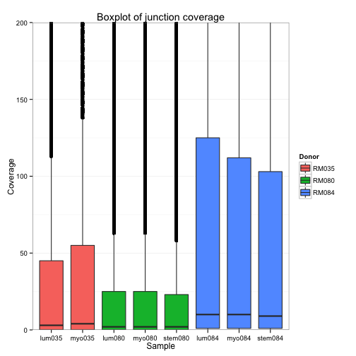

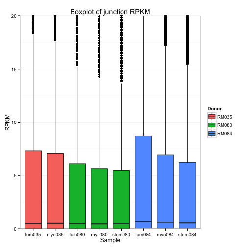

### Junction RPKM clustering

- Sample clustering on junction RPKM with spearman correlation shows clustering on cell types as well.

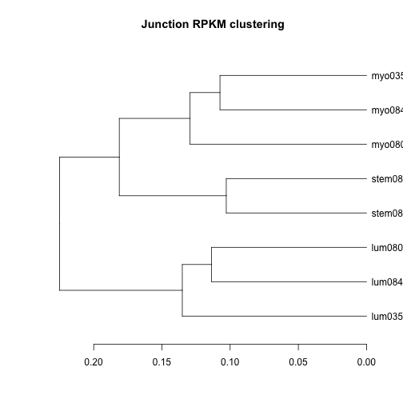

### Isoform junction validation

- For strand specific libraries, about **40%** of previously identified exons (**50%** genes) have junctions with enough coverage for validation. However, **more than 99%** of them have junction support.
- For non-strand specific libraries, only about **20-30%** isoform genes have enough junction coverage for validation, and among them **75-80%** genes have support from junction reads.
- Venn diagram of isoforms in RM080 is similar to RM084, with the common isoforms shared by different cell types having less ratio of being validated.
- Venn diagram of isoforms between same cell types in different individuals show similar patterns. The **majority** of isoforms are **shared** among different individual. However, isoforms in strand specific libraries (RM084) have **much higher** ratio of being validated.

|  | No.isoform.exons | No.isoform.genes | No.exons.with.junction.cov | No.genes.with.junction.cov | No.exons.with.junction.support | No.genes.with.junction.support |
| --- | --- | --- | --- | --- | --- | --- |
| lum084_myo084 | 8630 | 2381 | 3618 | 1228 | 3604 | 1217 |
| lum084_stem084 | 8948 | 2429 | 4226 | 1411 | 4217 | 1404 |
| myo084_stem084 | 8619 | 2427 | 3346 | 1247 | 3333 | 1238 |
| lum080_myo080 | 12871 | 2325 | 1687 | 509 | 1235 | 397 |
| lum080_stem080 | 8688 | 2345 | 1559 | 686 | 1232 | 559 |
| myo080_stem080 | 8448 | 2390 | 1105 | 548 | 791 | 427 |
| lum035_myo035 | 12911 | 2341 | 3536 | 817 | 2324 | 619 |

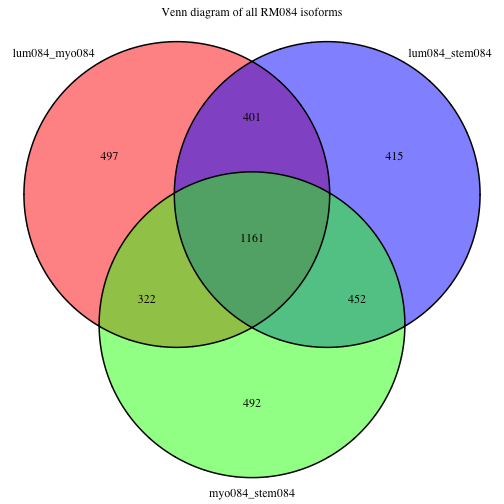

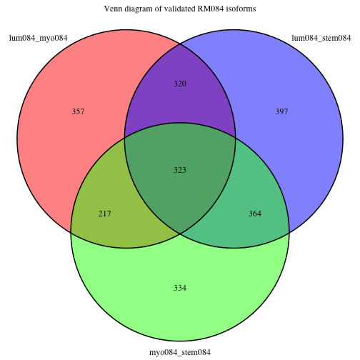

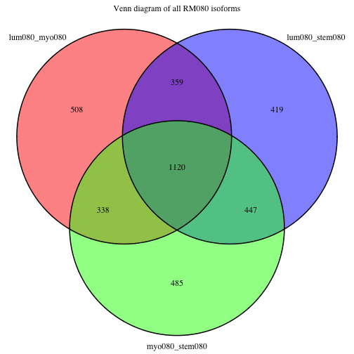

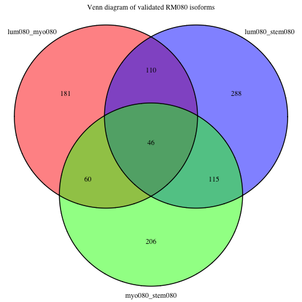

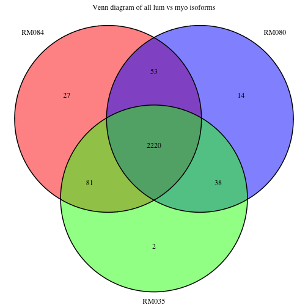

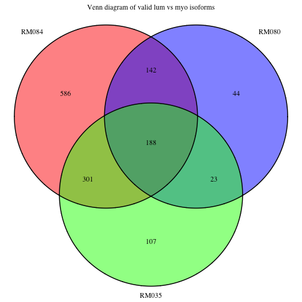

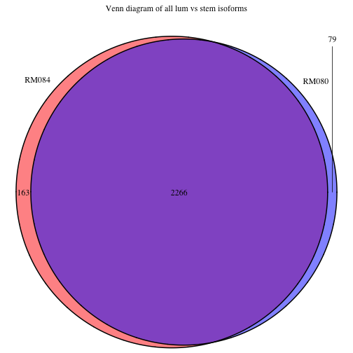

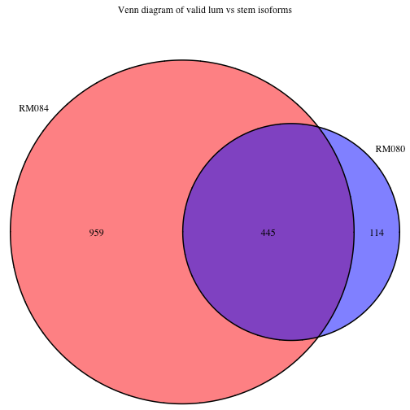

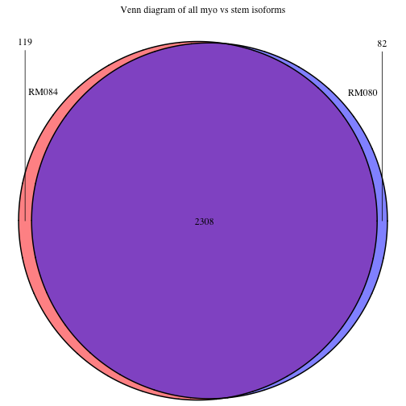

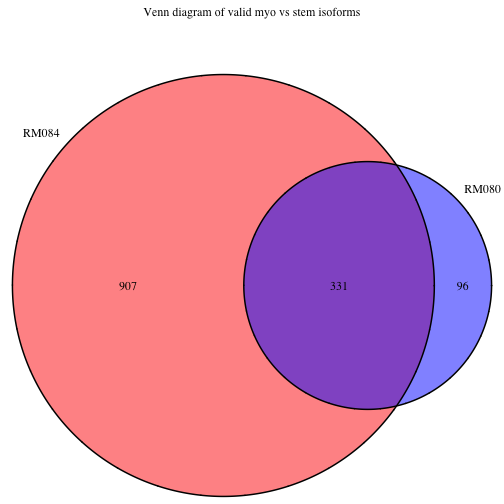

### No. of exons for DE genes / isoform genes

- DE genes have roughly the same No. of exons as all expressed genes.
- Identified isoforms have slightly more No. of exons than DE genes and all expressed genes.

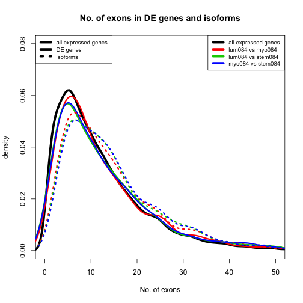

### Isoform genes in DE genes with small No. of exons

If a gene has only a few exons (\( \le \) 5 exons), and one exon is absent in one sample, i.e. isoform, the absence can bias the overall gene RPKM and this gene may be identified as a DE gene. Check if there are such cases.  
For DE gene with small No. of exons:

- If it is in fact an isoform, not DE gene, only one / few exons in this gene should be differentially expressed.
- If it is a truly DE gene, all exons should be differentially expressed.

  Proportion of DE exons for DE genes with \( \le \) 5 exons: (DE exons: fold change \( \ge \) 2)
- Proportion of DE exons < 1 for the few genes are due to exons not expressed in either samples.
- **There is no evidence for isoforms genes identified as DE genes.**

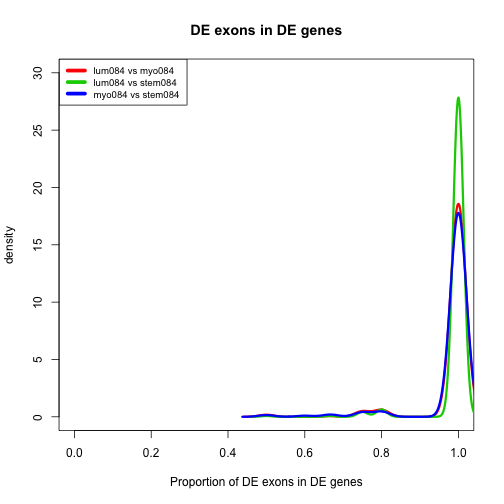

### Position of isoform exons on the gene

- In general, there are more alternative spliced exons at the **two ends** of genes.

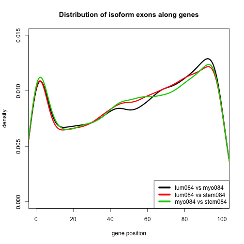

- Exon usage along the gene for all multi-transcript genes

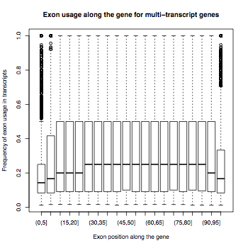

### Venn Diagram with average expression level, average No. of exons and average exon length

- Common isoforms shared among different comparisons have **much lower ratio of being validated**.
- Isoforms have **much lower** expression level than all expressed genes.
- On average, common isoforms between different comparisons have **lower expression level** than comparison-specific isoforms.
- In general, compared to all isoforms identified, validated isoforms do **not** have lower expression levels. Our validation approach is not biased towards highly expressed genes.
- Average No. of exons are very **similar** in different sections of the Venn diagram, between all, validated isoforms and all expressed genes.
- Average length of isoform exons are **shorter** than all expressed genes, and validated isoform exons are **sligtly shorter** than all isoforms in general but the difference is not statistically significant (p = 0.39).

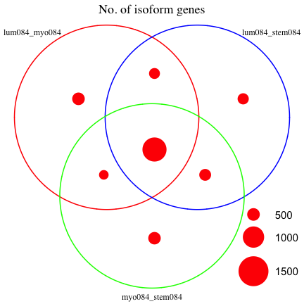

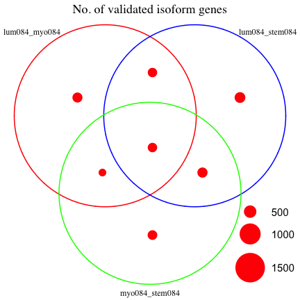

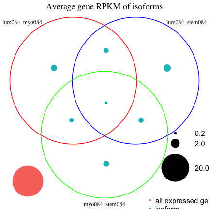

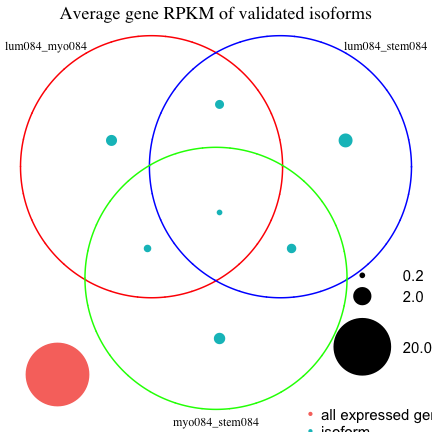

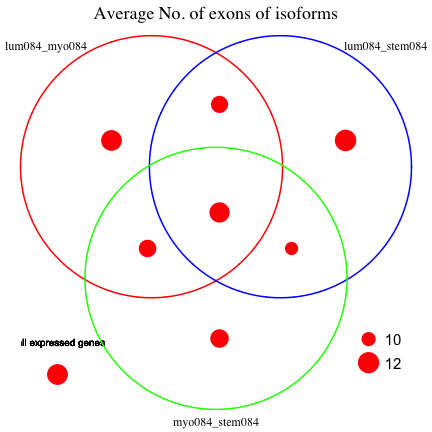

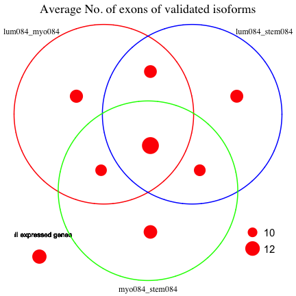

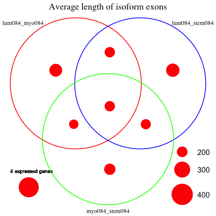

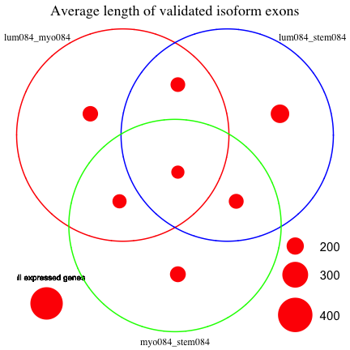

### Enrichment of all isoform genes and validated isoform genes for each section on the Venn diagram

- Multifunctional correction by ermineJ eliminates general terms and brings more specific terms. Use ermineJ for all GO analysis instead of DAVID.

#### lum084 vs myo084

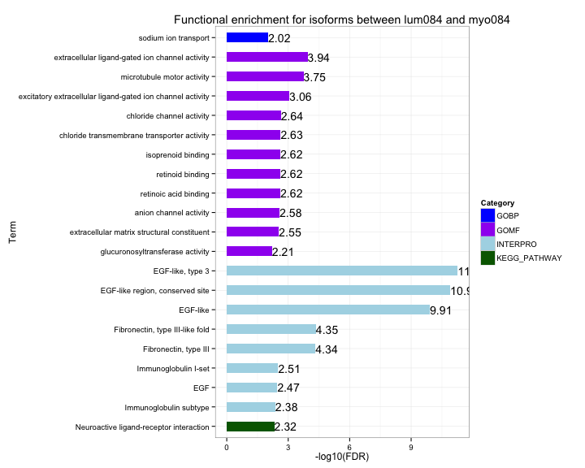

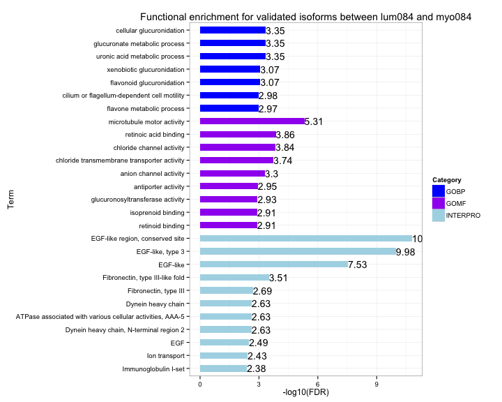

#### lum084 vs stem084

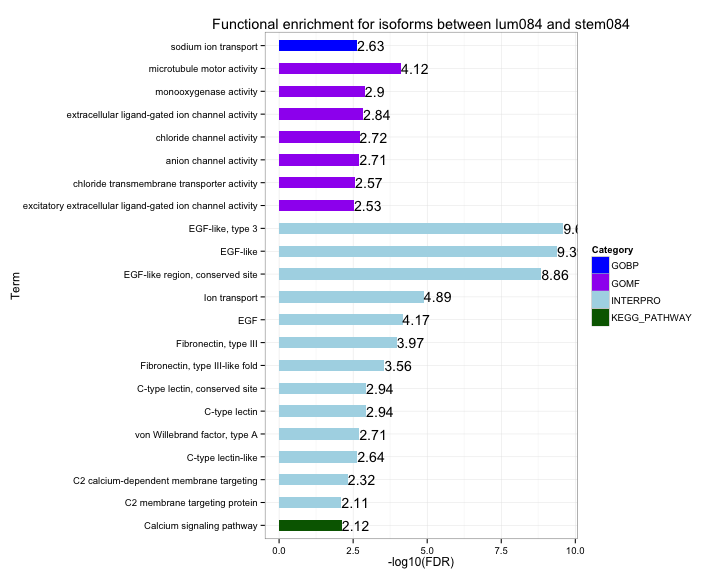

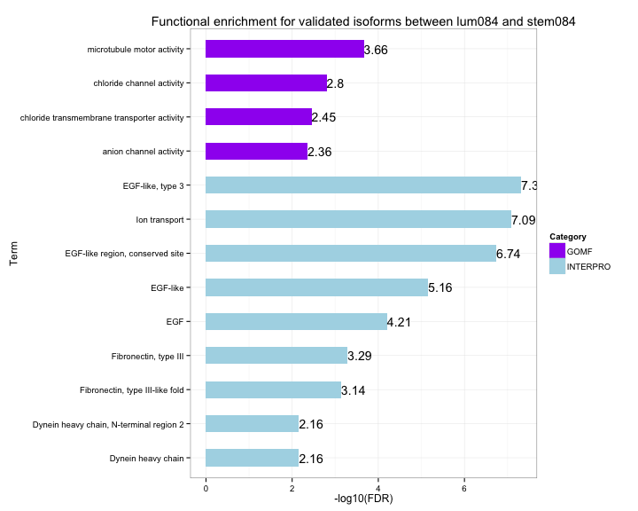